# Lab 4A

Principal Components Analysis

2021

In this lab you perform a PCA to a personality test, a bag of words and photo’s of faces.

For this lab you need the packages `stylo` and `psych`, and the data sets in `Profession.Rdata` and `faces.RData`.

# Personality types

The file “Profession.Rdata” contains the data set `Profession` with preference scores of 5389 subjects on 48 professions. The professions are subdivided in 6 sets of 8, with each set corresponding to different personality type (e.g. items R1 to R8 are professions that are supposed to be appealing to personality type “R = Realistic (Doers)”). The code book for the data is `Profession.txt`. The aim of the analysis is to find a principal component for each of the six personality types.

1. Load the data file “Profession.Rdata”, and display the scree plot for the `profession` data. How many PCs does the plot suggest?

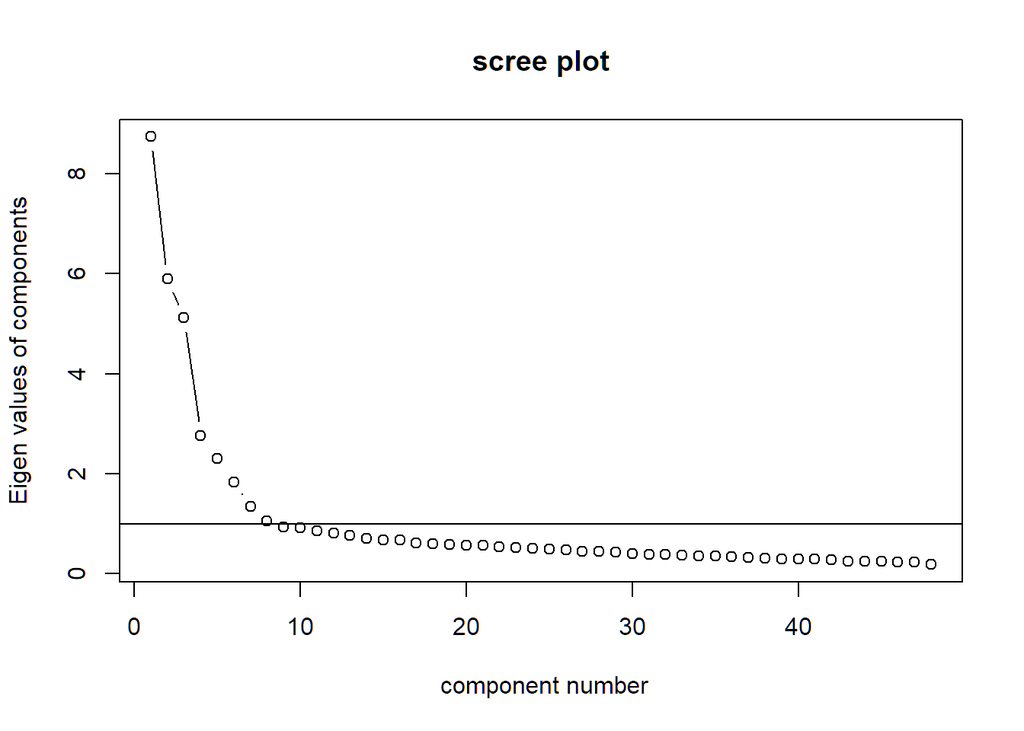

```r
load("Profession.RData")

VSS.scree(Profession)
```

1. There seem to be 7 or 8 PCs with an eigenvalue > 1, but we will ignore the 7th and 8th component. Perform a PCA that extracts 6 factors without rotation, and save the object as `prof_pca`.

```r
prof_pca <- principal(Profession, nfactors = 6, rotate = "none")
```

3. Display the `loadings` of the first 6 components with the function `print()`, and set the cutoff to 0.4. Do the loadings correspond to the personality types?

```r
print(loadings(prof_pca), cutoff=0.4)
```

```
##
## Loadings:
##    PC1    PC2    PC3    PC4    PC5    PC6
## R1  0.487
## R2  0.521
## R3  0.412
## R4  0.529        -0.421
## R5  0.497
## R6  0.532        -0.416
## R7  0.563
## R8  0.547
## I1                       0.432
## I2         0.417
## I3         0.409 -0.484
## I4  0.421
## I5               -0.500  0.432
## I6  0.400  0.450 -0.422
## I7  0.417        -0.503  0.414
## I8  0.440        -0.489
## A1         0.537
## A2         0.598
## A3         0.493
## A4         0.606
## A5         0.609
## A6         0.539
## A7
## A8         0.536
## S1                0.444
## S2
## S3                0.441
## S4
## S5                0.538
## S6                0.454
## S7                0.407
## S8
## E1  0.405                             -0.462
## E2                0.421
## E3  0.529
## E4                0.404
## E5  0.486
## E6  0.443         0.488
## E7  0.405                             -0.451
## E8  0.514
## C1  0.501 -0.474
## C2  0.559 -0.415
## C3  0.555 -0.503
## C4  0.509 -0.455
## C5  0.514
## C6  0.555
## C7  0.533 -0.430
## C8  0.590 -0.491
##
##                  PC1   PC2   PC3   PC4   PC5   PC6
## SS loadings    8.736 5.895 5.114 2.757 2.307 1.839
## Proportion Var 0.182 0.123 0.107 0.057 0.048 0.038
## Cumulative Var 0.182 0.305 0.411 0.469 0.517 0.555
```

4. Rerun the PCA with the default “varimax” rotation and save the result as `prof_rot`, and display the rotated component loadings. Did the rotation help interpretation of the personality types?

```r
prof_rot <- principal(Profession, nfactors = 6)
print(loadings(prof_rot), cutoff = 0.4)
```

```
##
## Loadings:
##    RC1    RC5    RC4    RC2    RC3    RC6
## R1         0.502
## R2         0.771
## R3         0.640
## R4         0.642
## R5         0.744
## R6         0.784
## R7         0.723
## R8         0.806
## I1                0.629
## I2                0.693
## I3                0.818
## I4                0.668
## I5                0.855
## I6                0.761
## I7                0.825
## I8                0.575
## A1                       0.709
## A2                       0.759
## A3                       0.620
## A4                       0.783
## A5                       0.751
## A6                       0.740
## A7
## A8                       0.711
## S1                              0.592
## S2                              0.651
## S3                              0.742
## S4                              0.481
## S5                              0.795
## S6                              0.670
## S7                              0.705
## S8                              0.728
## E1                                     0.676
## E2                                     0.602
## E3                                     0.642
## E4                                     0.524
## E5                                     0.575
## E6                                     0.717
## E7                                     0.694
## E8                                     0.456
## C1  0.758
## C2  0.660
## C3  0.815
## C4  0.775
## C5  0.733
## C6  0.673
## C7  0.667
## C8  0.786
##
##                  RC1   RC5   RC4   RC2   RC3   RC6
## SS loadings    5.158 4.710 4.647 4.254 4.146 3.733
## Proportion Var 0.107 0.098 0.097 0.089 0.086 0.078
## Cumulative Var 0.107 0.206 0.302 0.391 0.477 0.555
```

5. To get some idea of the distribution of the PCs, display their means and standard deviations, rounded to 4 decimals.

```r
data.frame(mean  = apply(prof_pca$scores, 2 , mean), sd = apply(prof_pca$scores, 2, sd)) %>% round(4)
```

|  | mean | sd |
| --- | --- | --- |
| PC1 | 0 | 1 |
| PC2 | 0 | 1 |
| PC3 | 0 | 1 |
| PC4 | 0 | 1 |
| PC5 | 0 | 1 |
| PC6 | 0 | 1 |

6. Rename the PCs in the names of the personality types in the code book (e.g. Doers, Thinkers, etc), and save the result.

```r
d <- as.data.frame(prof_rot$scores)
names(d) <- c("Organizer", "Doer", "Thinker", "Creator", "Helper", "Persuader")
```

6. Display the scores of a random sample of 5 persons from the data, and interpret this persons personality profile.

```r
d[sample(5389, 5), ] %>%  round(1)
```

|  | Organizer | Doer | Thinker | Creator | Helper | Persuader |
| --- | --- | --- | --- | --- | --- | --- |
| 37 | -0.7 | -0.3 | -1.0 | 0.1 | 1.6 | 0.2 |
| 2103 | -0.8 | -0.2 | 1.0 | 1.3 | -0.5 | 0.1 |
| 1178 | -1.1 | 0.1 | -0.1 | 1.0 | -0.8 | 1.9 |
| 3622 | -1.0 | -1.0 | 0.1 | 0.4 | 2.1 | -0.9 |
| 1879 | -0.8 | 2.5 | -0.4 | -0.5 | -1.0 | 0.1 |

# Text analysis

In this exercise you use PCA to analyze word frequencies in nine novels by the the three Bronthe sisters and Jane Austin. The data for this analysis are in the `novels` object of the package `stylo`.

1. Load the `novels` object with the command `data()`, and summarize the object with the function `summary()`.

```r
data(novels)
summary(novels)
```

```
##
## Function call:
## load.corpus(files = dir())
##
## Number of texts/samples:         9
## Total number of units:           88810
## Number of units in samples:
##
##                ABronte_Agnes...  6190
##               ABronte_Tenant...  15504
##                  Austen_Emma...  13877
##                 Austen_Pride...  2267
##                 Austen_Sense...  10598
##                 CBronte_Jane...  4061
##            CBronte_Professor...  7799
##             CBronte_Villette...  17688
##            EBronte_Wuthering...  10826
##
## Depending if the corpus has been tokenized or not, the "units" mean
## tokens (words, word pairs, POS-tags, character n-grams, etc.),
## or strings of text (usually paragraphs) ending with a newline char.
```

The code below prepares the data for the PCA. It extracts the relative frequencies of words that occur most frequently in the novels.

```
tokens   <- txt.to.words.ext(novels,
                             preserve.case = FALSE)

frequent <- make.frequency.list(tokens,
                                head = 10)

freqs    <- make.table.of.frequencies(tokens,
                                      features = frequent)
```

2. Copy-paste the code, run it and inspect the content of the object `freqs`.

```
## $dim
## [1]  9 10
##
## $dimnames
## $dimnames[[1]]
## [1] "ABronte_Agnes"     "ABronte_Tenant"    "Austen_Emma"
## [4] "Austen_Pride"      "Austen_Sense"      "CBronte_Jane"
## [7] "CBronte_Professor" "CBronte_Villette"  "EBronte_Wuthering"
##
## $dimnames[[2]]
##  [1] "the" "and" "to"  "i"   "of"  "a"   "in"  "was" "her" "it"
##
##
## $class
## [1] "stylo.data"
##
## $call
## make.table.of.frequencies(corpus = tokens, features = frequent)
```

3. Perform a PCA on the `freqs` object with the function `prcomp()`, and save the result.

```r
author_pca <- prcomp(freqs)
```

4. Display the scree plot of the `prcomp` object. According to the elbow criterion, how many PCs do we need to extract?

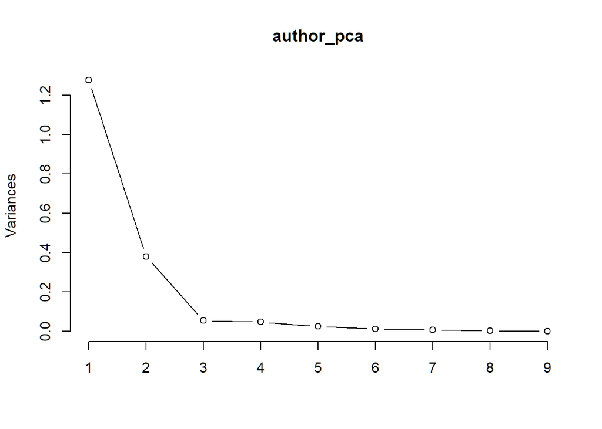

```r
screeplot(author_pca, type="line")
```

5. Display the biplot of PC1 and PC2, and interpret the plot. Which of the four authors uses “a” and “the” most frequently, and which authors are characterized by the frequent use of “and”?

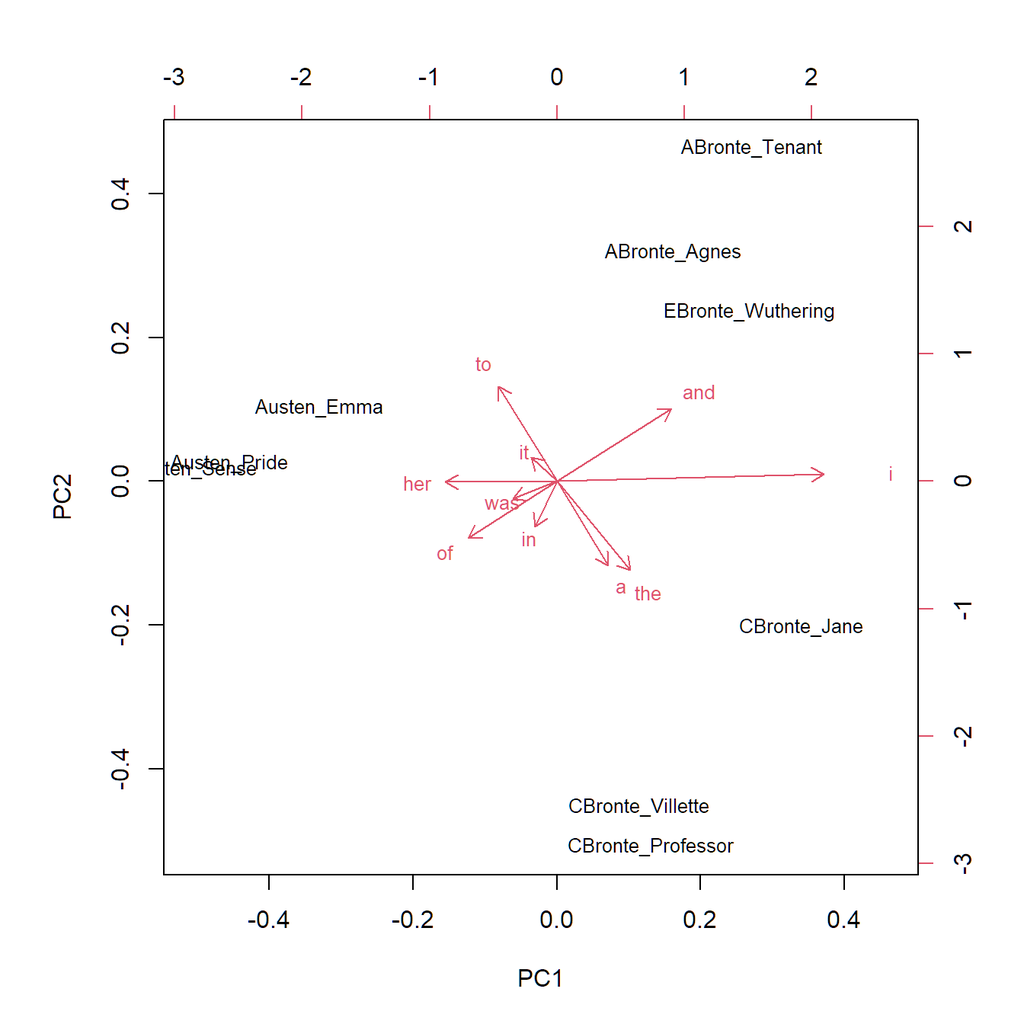

```r
biplot(author_pca, cex = .8)
```

# Eigenfaces

The data set for this exercise is called `faces` and in the file `faces.RData`. The data for this analysis consist of 2410 pictures of faces of which the pixels are converted to gray scales in the range $(0, 255)$. The pictures all have 8064 pixels $(96\times84)$. The aim of the analysis to is to create a reduced number of principal components that summarize stereotype faces, a.k.a *eigenfaces*.

1. Load this file into workspace with the function `load()`.

```r
load("faces.RData")
```

2. To get some idea of what the data look like, display a summary columns of the first 5 columns (faces) of `faces`.

```r
summary(faces[, 1:5])
```

```
##        V1               V2              V3               V4
##  Min.   : 12.00   Min.   :  4.5   Min.   :  2.25   Min.   :  0.00
##  1st Qu.: 90.75   1st Qu.: 86.5   1st Qu.: 58.75   1st Qu.:  5.25
##  Median :114.75   Median :113.0   Median :104.25   Median :  8.75
##  Mean   :114.59   Mean   :116.5   Mean   :106.80   Mean   : 15.72
##  3rd Qu.:137.75   3rd Qu.:148.5   3rd Qu.:153.75   3rd Qu.: 13.75
##  Max.   :238.00   Max.   :247.0   Max.   :255.00   Max.   :255.00
##        V5
##  Min.   : 11.5
##  1st Qu.: 84.5
##  Median :107.9
##  Mean   :106.0
##  3rd Qu.:126.8
##  Max.   :211.2
```

[output not shown]

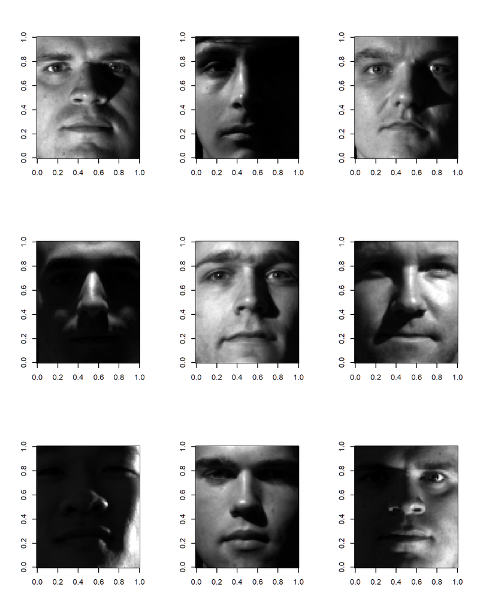

4. Perform a PCA on `faces` using `prcomp()` (may take a while), and save the result.

```r
faces_pca <- prcomp(faces)
```

5. Apply the code given above to plot eigenfaces of the first 9 principal components.

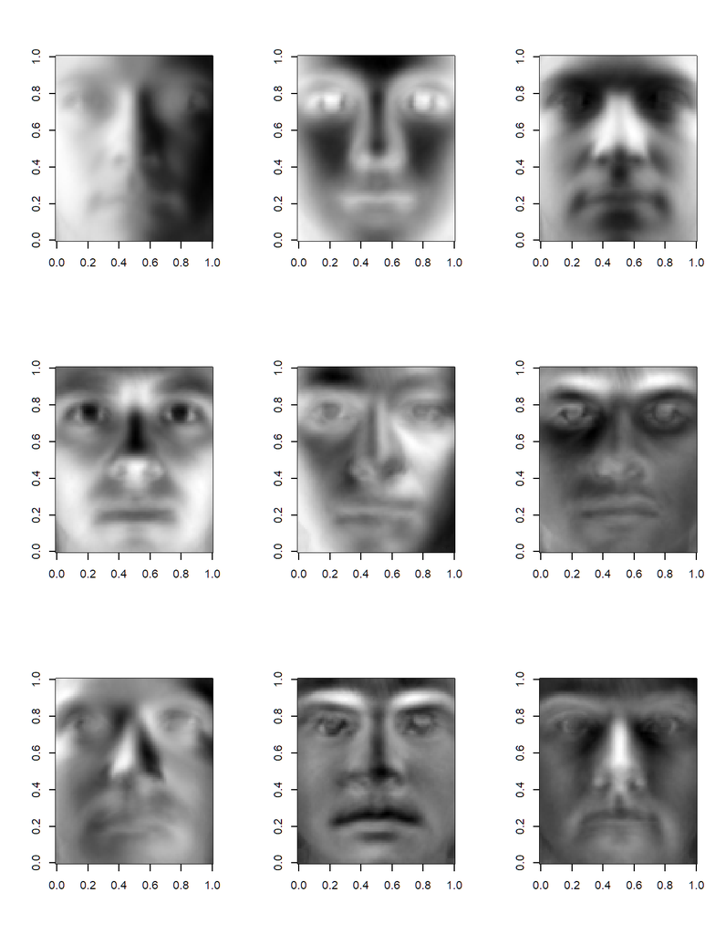

```r
par(mfrow=c(3, 3))
for(i in 1:9){
  face <- matrix(rev(faces_pca$x[, i]), nrow = 84, ncol = 96)
  image(face, col = gray(0:255 / 255 ))
}
```

6. Also plot the eigenfaces of the last 9 principal components. How would you interpret the results?

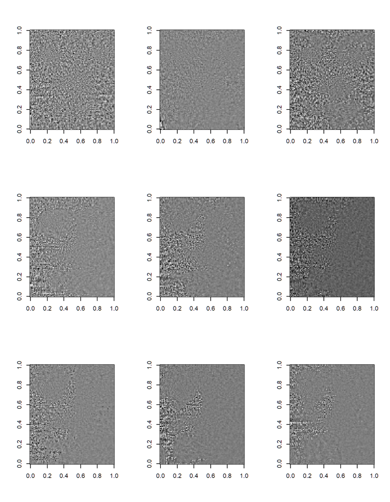

7. Plots of the component scores give nonsensical but inspiring results. Run the code below and marvel!

```
par(mfrow=c(3, 2))
for(i in 1:6)plot(faces_pca$scores[, i])
```

[figure not shown]

END OF LAB